# Risk Factor Analysis

## Outcome Variable

**Outcome Variable:** haz

## Predictor Variables

**Intervention Variable:** anywast06

**Adjustment Set:**

- arm
- sex
- brthmon
- W_mage
- meducyrs
- hhwealth_quart
- W_nrooms
- month
- W_parity
- delta_W_mage
- delta_meducyrs
- delta_hhwealth_quart
- delta_W_nrooms
- delta_month
- delta_W_parity

## Stratifying Variables

The analysis was stratified on these variable(s):

- agecat
- studyid
- country

## Data Summary

| agecat | studyid | country | anywast06 | n_cell | n | outcome_variable |
| --- | --- | --- | --- | --- | --- | --- |
| Birth | CMC-V-BCS-2002 | INDIA | 0 | 37 | 92 | haz |
| Birth | CMC-V-BCS-2002 | INDIA | 1 | 55 | 92 | haz |
| Birth | CMIN | BANGLADESH | 0 | 15 | 20 | haz |
| Birth | CMIN | BANGLADESH | 1 | 5 | 20 | haz |
| Birth | CONTENT | PERU | 0 | 2 | 2 | haz |
| Birth | CONTENT | PERU | 1 | 0 | 2 | haz |
| Birth | EE | PAKISTAN | 0 | 156 | 240 | haz |
| Birth | EE | PAKISTAN | 1 | 84 | 240 | haz |
| Birth | GMS-Nepal | NEPAL | 0 | 422 | 684 | haz |
| Birth | GMS-Nepal | NEPAL | 1 | 262 | 684 | haz |
| Birth | IRC | INDIA | 0 | 164 | 388 | haz |
| Birth | IRC | INDIA | 1 | 224 | 388 | haz |
| Birth | Keneba | GAMBIA | 0 | 994 | 1542 | haz |
| Birth | Keneba | GAMBIA | 1 | 548 | 1542 | haz |
| Birth | MAL-ED | BANGLADESH | 0 | 177 | 229 | haz |
| Birth | MAL-ED | BANGLADESH | 1 | 52 | 229 | haz |
| Birth | MAL-ED | BRAZIL | 0 | 62 | 65 | haz |
| Birth | MAL-ED | BRAZIL | 1 | 3 | 65 | haz |
| Birth | MAL-ED | INDIA | 0 | 33 | 47 | haz |
| Birth | MAL-ED | INDIA | 1 | 14 | 47 | haz |
| Birth | MAL-ED | NEPAL | 0 | 23 | 27 | haz |
| Birth | MAL-ED | NEPAL | 1 | 4 | 27 | haz |
| Birth | MAL-ED | PERU | 0 | 223 | 233 | haz |
| Birth | MAL-ED | PERU | 1 | 10 | 233 | haz |
| Birth | MAL-ED | SOUTH AFRICA | 0 | 101 | 122 | haz |
| Birth | MAL-ED | SOUTH AFRICA | 1 | 21 | 122 | haz |
| Birth | MAL-ED | TANZANIA, UNITED REPUBLIC OF | 0 | 119 | 124 | haz |
| Birth | MAL-ED | TANZANIA, UNITED REPUBLIC OF | 1 | 5 | 124 | haz |
| Birth | PROVIDE | BANGLADESH | 0 | 396 | 539 | haz |
| Birth | PROVIDE | BANGLADESH | 1 | 143 | 539 | haz |

[output cut: 70 more lines]

The following strata were considered:

- agecat: 24 months, studyid: CMC-V-BCS-2002, country: INDIA
- agecat: 24 months, studyid: CMIN, country: BANGLADESH
- agecat: 24 months, studyid: CONTENT, country: PERU
- agecat: 24 months, studyid: EE, country: PAKISTAN
- agecat: 24 months, studyid: GMS-Nepal, country: NEPAL
- agecat: 24 months, studyid: IRC, country: INDIA
- agecat: 24 months, studyid: Keneba, country: GAMBIA
- agecat: 24 months, studyid: MAL-ED, country: BANGLADESH
- agecat: 24 months, studyid: MAL-ED, country: BRAZIL
- agecat: 24 months, studyid: MAL-ED, country: INDIA
- agecat: 24 months, studyid: MAL-ED, country: NEPAL
- agecat: 24 months, studyid: MAL-ED, country: PERU
- agecat: 24 months, studyid: MAL-ED, country: SOUTH AFRICA
- agecat: 24 months, studyid: MAL-ED, country: TANZANIA, UNITED REPUBLIC OF
- agecat: 24 months, studyid: PROVIDE, country: BANGLADESH
- agecat: 24 months, studyid: TanzaniaChild2, country: TANZANIA, UNITED REPUBLIC OF
- agecat: 6 months, studyid: CMC-V-BCS-2002, country: INDIA
- agecat: 6 months, studyid: CMIN, country: BANGLADESH
- agecat: 6 months, studyid: CONTENT, country: PERU
- agecat: 6 months, studyid: EE, country: PAKISTAN
- agecat: 6 months, studyid: GMS-Nepal, country: NEPAL
- agecat: 6 months, studyid: Guatemala BSC, country: GUATEMALA
- agecat: 6 months, studyid: IRC, country: INDIA
- agecat: 6 months, studyid: Keneba, country: GAMBIA
- agecat: 6 months, studyid: MAL-ED, country: BANGLADESH
- agecat: 6 months, studyid: MAL-ED, country: BRAZIL
- agecat: 6 months, studyid: MAL-ED, country: INDIA
- agecat: 6 months, studyid: MAL-ED, country: NEPAL
- agecat: 6 months, studyid: MAL-ED, country: PERU
- agecat: 6 months, studyid: MAL-ED, country: SOUTH AFRICA
- agecat: 6 months, studyid: MAL-ED, country: TANZANIA, UNITED REPUBLIC OF
- agecat: 6 months, studyid: PROVIDE, country: BANGLADESH
- agecat: 6 months, studyid: ResPak, country: PAKISTAN
- agecat: 6 months, studyid: TanzaniaChild2, country: TANZANIA, UNITED REPUBLIC OF
- agecat: Birth, studyid: CMC-V-BCS-2002, country: INDIA
- agecat: Birth, studyid: CMIN, country: BANGLADESH
- agecat: Birth, studyid: CONTENT, country: PERU
- agecat: Birth, studyid: EE, country: PAKISTAN
- agecat: Birth, studyid: GMS-Nepal, country: NEPAL
- agecat: Birth, studyid: IRC, country: INDIA
- agecat: Birth, studyid: Keneba, country: GAMBIA
- agecat: Birth, studyid: MAL-ED, country: BANGLADESH
- agecat: Birth, studyid: MAL-ED, country: BRAZIL
- agecat: Birth, studyid: MAL-ED, country: INDIA
- agecat: Birth, studyid: MAL-ED, country: NEPAL
- agecat: Birth, studyid: MAL-ED, country: PERU
- agecat: Birth, studyid: MAL-ED, country: SOUTH AFRICA
- agecat: Birth, studyid: MAL-ED, country: TANZANIA, UNITED REPUBLIC OF
- agecat: Birth, studyid: PROVIDE, country: BANGLADESH
- agecat: Birth, studyid: ResPak, country: PAKISTAN

### Dropped Strata

Some strata were dropped due to rare outcomes:

- agecat: Birth, studyid: CONTENT, country: PERU
- agecat: Birth, studyid: MAL-ED, country: BRAZIL
- agecat: Birth, studyid: MAL-ED, country: NEPAL
- agecat: 6 months, studyid: CONTENT, country: PERU
- agecat: 24 months, studyid: CONTENT, country: PERU
- agecat: 24 months, studyid: TanzaniaChild2, country: TANZANIA, UNITED REPUBLIC OF

## Methods Detail

We’re interested in the causal parameters $E[Y_a]$ for all values of $a \in \mathcal{A}$. These parameters represent the mean outcome if, possibly contrary to fact, we intervened to set all units to have $A=a$. Under the randomization and positivity assumptions, these are identified by the statistical parameters $\psi_a=E_W[E_{Y|A,W}(Y|A=a,W)]$. In addition, we’re interested in the mean of $Y$, $E[Y]$ under no intervention (the observed mean). We will estimate these parameters by using SuperLearner to fit the relevant likelihood factors – $E_{Y|A,W}(Y|A=a,W)$ and $p(A=a|W)$, and then updating our likelihood fit using a joint TMLE.

For unadjusted analyses ($W=\{\}$), initial likelihoods were estimated using Lrnr_glm to estimate the simple $E(Y|A)$ and Lrnr_mean to estimate $p(A)$. For adjusted analyses, a small library containing Lrnr_glmnet, Lrnr_xgboost, and Lrnr_mean was used.

Having estimated these parameters, we will then use the delta method to estimate relative risks and attributable risks relative to a prespecified baseline level of $A$.

# Results Detail

## Results Plots

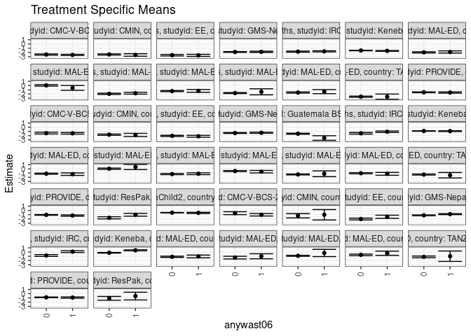

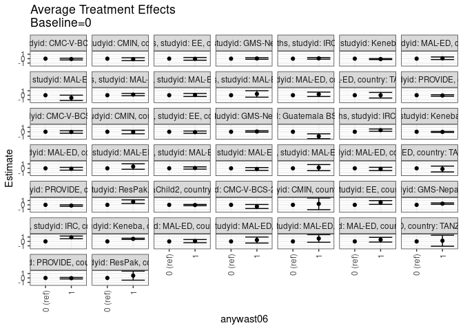

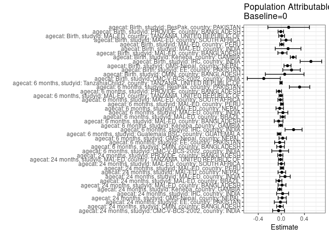

## Results Table

### Parameter: TSM

| agecat | studyid | country | intervention_level | baseline_level | estimate | ci_lower | ci_upper |
| --- | --- | --- | --- | --- | --- | --- | --- |
| Birth | CMC-V-BCS-2002 | INDIA | 0 | NA | -0.6574819 | -0.9980281 | -0.3169356 |
| Birth | CMC-V-BCS-2002 | INDIA | 1 | NA | -1.0294828 | -1.3219468 | -0.7370189 |
| Birth | CMIN | BANGLADESH | 0 | NA | -1.2613333 | -1.7710980 | -0.7515686 |
| Birth | CMIN | BANGLADESH | 1 | NA | -1.0280000 | -2.2553082 | 0.1993082 |
| Birth | EE | PAKISTAN | 0 | NA | -2.0377362 | -2.2513474 | -1.8241250 |
| Birth | EE | PAKISTAN | 1 | NA | -1.4981720 | -1.8667641 | -1.1295798 |
| Birth | GMS-Nepal | NEPAL | 0 | NA | -1.1527631 | -1.2534598 | -1.0520663 |
| Birth | GMS-Nepal | NEPAL | 1 | NA | -0.8759561 | -0.9976706 | -0.7542415 |
| Birth | IRC | INDIA | 0 | NA | -0.8211439 | -1.0368163 | -0.6054715 |
| Birth | IRC | INDIA | 1 | NA | 0.0964050 | -0.1200908 | 0.3129008 |
| Birth | Keneba | GAMBIA | 0 | NA | -0.1729418 | -0.2475333 | -0.0983503 |
| Birth | Keneba | GAMBIA | 1 | NA | 0.4124458 | 0.3009022 | 0.5239894 |
| Birth | MAL-ED | BANGLADESH | 0 | NA | -1.1234625 | -1.2716556 | -0.9752694 |
| Birth | MAL-ED | BANGLADESH | 1 | NA | -1.0456503 | -1.3715039 | -0.7197967 |
| Birth | MAL-ED | INDIA | 0 | NA | -1.3209795 | -1.6411741 | -1.0007849 |
| Birth | MAL-ED | INDIA | 1 | NA | -1.0027150 | -1.5976399 | -0.4077901 |
| Birth | MAL-ED | PERU | 0 | NA | -0.8901728 | -1.0073254 | -0.7730202 |
| Birth | MAL-ED | PERU | 1 | NA | -0.2225424 | -1.0736756 | 0.6285908 |
| Birth | MAL-ED | SOUTH AFRICA | 0 | NA | -0.6698564 | -0.8553632 | -0.4843496 |
| Birth | MAL-ED | SOUTH AFRICA | 1 | NA | -0.2809471 | -0.7856200 | 0.2237257 |
| Birth | MAL-ED | TANZANIA, UNITED REPUBLIC OF | 0 | NA | -1.1432773 | -1.3541075 | -0.9324471 |
| Birth | MAL-ED | TANZANIA, UNITED REPUBLIC OF | 1 | NA | -0.9860000 | -2.2167588 | 0.2447588 |
| Birth | PROVIDE | BANGLADESH | 0 | NA | -0.8762238 | -0.9611304 | -0.7913173 |
| Birth | PROVIDE | BANGLADESH | 1 | NA | -0.9233527 | -1.0784205 | -0.7682849 |
| Birth | ResPak | PAKISTAN | 0 | NA | -1.1075057 | -1.5601610 | -0.6548504 |
| Birth | ResPak | PAKISTAN | 1 | NA | -0.5758853 | -1.4938639 | 0.3420933 |
| 6 months | CMC-V-BCS-2002 | INDIA | 0 | NA | -1.4046564 | -1.6162859 | -1.1930269 |
| 6 months | CMC-V-BCS-2002 | INDIA | 1 | NA | -1.4470202 | -1.6377990 | -1.2562415 |
| 6 months | CMIN | BANGLADESH | 0 | NA | -1.7712149 | -1.9211407 | -1.6212891 |
| 6 months | CMIN | BANGLADESH | 1 | NA | -1.8324528 | -2.2075345 | -1.4573710 |

[output cut: 58 more lines]

### Parameter: E(Y)

| agecat | studyid | country | intervention_level | baseline_level | estimate | ci_lower | ci_upper |
| --- | --- | --- | --- | --- | --- | --- | --- |
| Birth | CMC-V-BCS-2002 | INDIA | NA | NA | -0.9611957 | -1.1776967 | -0.7446946 |
| Birth | CMIN | BANGLADESH | NA | NA | -1.2030000 | -1.6953191 | -0.7106809 |
| Birth | EE | PAKISTAN | NA | NA | -1.8608750 | -2.0482045 | -1.6735455 |
| Birth | GMS-Nepal | NEPAL | NA | NA | -1.0454532 | -1.1235003 | -0.9674062 |
| Birth | IRC | INDIA | NA | NA | -0.3080412 | -0.4687931 | -0.1472894 |
| Birth | Keneba | GAMBIA | NA | NA | 0.0325486 | -0.0310420 | 0.0961393 |
| Birth | MAL-ED | BANGLADESH | NA | NA | -1.1041048 | -1.2383048 | -0.9699048 |
| Birth | MAL-ED | INDIA | NA | NA | -1.2036170 | -1.4976814 | -0.9095527 |
| Birth | MAL-ED | PERU | NA | NA | -0.8827897 | -1.0001058 | -0.7654736 |
| Birth | MAL-ED | SOUTH AFRICA | NA | NA | -0.5877869 | -0.7622273 | -0.4133464 |
| Birth | MAL-ED | TANZANIA, UNITED REPUBLIC OF | NA | NA | -1.1369355 | -1.3453337 | -0.9285373 |
| Birth | PROVIDE | BANGLADESH | NA | NA | -0.8851020 | -0.9601332 | -0.8100709 |
| Birth | ResPak | PAKISTAN | NA | NA | -0.9800000 | -1.4086438 | -0.5513562 |
| 6 months | CMC-V-BCS-2002 | INDIA | NA | NA | -1.4241872 | -1.5668135 | -1.2815609 |
| 6 months | CMIN | BANGLADESH | NA | NA | -1.7844376 | -1.9222926 | -1.6465825 |
| 6 months | EE | PAKISTAN | NA | NA | -2.0835567 | -2.2027557 | -1.9643578 |
| 6 months | GMS-Nepal | NEPAL | NA | NA | -1.3508392 | -1.4290633 | -1.2726152 |
| 6 months | Guatemala BSC | GUATEMALA | NA | NA | -1.5785476 | -1.6926664 | -1.4644288 |
| 6 months | IRC | INDIA | NA | NA | -1.2344062 | -1.3658524 | -1.1029600 |
| 6 months | Keneba | GAMBIA | NA | NA | -0.9116762 | -0.9588660 | -0.8644864 |
| 6 months | MAL-ED | BANGLADESH | NA | NA | -1.2049931 | -1.3222136 | -1.0877726 |
| 6 months | MAL-ED | BRAZIL | NA | NA | 0.0475758 | -0.0963508 | 0.1915023 |
| 6 months | MAL-ED | INDIA | NA | NA | -1.2115254 | -1.3298727 | -1.0931782 |
| 6 months | MAL-ED | NEPAL | NA | NA | -0.5615819 | -0.6741832 | -0.4489807 |
| 6 months | MAL-ED | PERU | NA | NA | -1.3236661 | -1.4316775 | -1.2156546 |
| 6 months | MAL-ED | SOUTH AFRICA | NA | NA | -1.0633202 | -1.1909180 | -0.9357224 |
| 6 months | MAL-ED | TANZANIA, UNITED REPUBLIC OF | NA | NA | -1.3687449 | -1.4907629 | -1.2467270 |
| 6 months | PROVIDE | BANGLADESH | NA | NA | -1.0916915 | -1.1661176 | -1.0172654 |
| 6 months | ResPak | PAKISTAN | NA | NA | -1.4314086 | -1.6374838 | -1.2253335 |
| 6 months | TanzaniaChild2 | TANZANIA, UNITED REPUBLIC OF | NA | NA | -0.5434389 | -0.5924056 | -0.4944722 |
| 24 months | CMC-V-BCS-2002 | INDIA | NA | NA | -2.5489071 | -2.6476125 | -2.4502017 |
| 24 months | CMIN | BANGLADESH | NA | NA | -2.5109504 | -2.6361514 | -2.3857494 |
| 24 months | EE | PAKISTAN | NA | NA | -2.6699900 | -2.8138051 | -2.5261749 |
| 24 months | GMS-Nepal | NEPAL | NA | NA | -1.8874180 | -1.9728588 | -1.8019773 |
| 24 months | IRC | INDIA | NA | NA | -1.7987775 | -1.8923914 | -1.7051636 |
| 24 months | Keneba | GAMBIA | NA | NA | -1.5774758 | -1.6295950 | -1.5253566 |
| 24 months | MAL-ED | BANGLADESH | NA | NA | -1.9783962 | -2.1050210 | -1.8517715 |
| 24 months | MAL-ED | BRAZIL | NA | NA | 0.0061144 | -0.1625850 | 0.1748138 |
| 24 months | MAL-ED | INDIA | NA | NA | -1.8861894 | -2.0110006 | -1.7613783 |
| 24 months | MAL-ED | NEPAL | NA | NA | -1.3075877 | -1.4270718 | -1.1881037 |
| 24 months | MAL-ED | PERU | NA | NA | -1.7524710 | -1.8736426 | -1.6312994 |
| 24 months | MAL-ED | SOUTH AFRICA | NA | NA | -1.6450595 | -1.7797240 | -1.5103950 |
| 24 months | MAL-ED | TANZANIA, UNITED REPUBLIC OF | NA | NA | -2.6455607 | -2.7807256 | -2.5103959 |
| 24 months | PROVIDE | BANGLADESH | NA | NA | -1.6024221 | -1.6857420 | -1.5191023 |

### Parameter: ATE

| agecat | studyid | country | intervention_level | baseline_level | estimate | ci_lower | ci_upper |
| --- | --- | --- | --- | --- | --- | --- | --- |
| Birth | CMC-V-BCS-2002 | INDIA | 0 | 0 | 0.0000000 | 0.0000000 | 0.0000000 |
| Birth | CMC-V-BCS-2002 | INDIA | 1 | 0 | -0.3720010 | -0.8299999 | 0.0859980 |
| Birth | CMIN | BANGLADESH | 0 | 0 | 0.0000000 | 0.0000000 | 0.0000000 |
| Birth | CMIN | BANGLADESH | 1 | 0 | 0.2333333 | -1.0956307 | 1.5622974 |
| Birth | EE | PAKISTAN | 0 | 0 | 0.0000000 | 0.0000000 | 0.0000000 |
| Birth | EE | PAKISTAN | 1 | 0 | 0.5395642 | 0.1142844 | 0.9648440 |
| Birth | GMS-Nepal | NEPAL | 0 | 0 | 0.0000000 | 0.0000000 | 0.0000000 |
| Birth | GMS-Nepal | NEPAL | 1 | 0 | 0.2768070 | 0.1187407 | 0.4348733 |
| Birth | IRC | INDIA | 0 | 0 | 0.0000000 | 0.0000000 | 0.0000000 |
| Birth | IRC | INDIA | 1 | 0 | 0.9175489 | 0.6089647 | 1.2261331 |
| Birth | Keneba | GAMBIA | 0 | 0 | 0.0000000 | 0.0000000 | 0.0000000 |
| Birth | Keneba | GAMBIA | 1 | 0 | 0.5853877 | 0.4515315 | 0.7192438 |
| Birth | MAL-ED | BANGLADESH | 0 | 0 | 0.0000000 | 0.0000000 | 0.0000000 |
| Birth | MAL-ED | BANGLADESH | 1 | 0 | 0.0778122 | -0.2808269 | 0.4364512 |
| Birth | MAL-ED | INDIA | 0 | 0 | 0.0000000 | 0.0000000 | 0.0000000 |
| Birth | MAL-ED | INDIA | 1 | 0 | 0.3182645 | -0.3626508 | 0.9991798 |
| Birth | MAL-ED | PERU | 0 | 0 | 0.0000000 | 0.0000000 | 0.0000000 |
| Birth | MAL-ED | PERU | 1 | 0 | 0.6676305 | -0.1920164 | 1.5272773 |
| Birth | MAL-ED | SOUTH AFRICA | 0 | 0 | 0.0000000 | 0.0000000 | 0.0000000 |
| Birth | MAL-ED | SOUTH AFRICA | 1 | 0 | 0.3889092 | -0.1500972 | 0.9279157 |
| Birth | MAL-ED | TANZANIA, UNITED REPUBLIC OF | 0 | 0 | 0.0000000 | 0.0000000 | 0.0000000 |
| Birth | MAL-ED | TANZANIA, UNITED REPUBLIC OF | 1 | 0 | 0.1572773 | -1.0914086 | 1.4059632 |
| Birth | PROVIDE | BANGLADESH | 0 | 0 | 0.0000000 | 0.0000000 | 0.0000000 |
| Birth | PROVIDE | BANGLADESH | 1 | 0 | -0.0471289 | -0.2240469 | 0.1297891 |
| Birth | ResPak | PAKISTAN | 0 | 0 | 0.0000000 | 0.0000000 | 0.0000000 |
| Birth | ResPak | PAKISTAN | 1 | 0 | 0.5316204 | -0.4988868 | 1.5621276 |
| 6 months | CMC-V-BCS-2002 | INDIA | 0 | 0 | 0.0000000 | 0.0000000 | 0.0000000 |
| 6 months | CMC-V-BCS-2002 | INDIA | 1 | 0 | -0.0423639 | -0.3250879 | 0.2403602 |
| 6 months | CMIN | BANGLADESH | 0 | 0 | 0.0000000 | 0.0000000 | 0.0000000 |
| 6 months | CMIN | BANGLADESH | 1 | 0 | -0.0612379 | -0.4653602 | 0.3428844 |

[output cut: 58 more lines]

### Parameter: PAR

| agecat | studyid | country | intervention_level | baseline_level | estimate | ci_lower | ci_upper |
| --- | --- | --- | --- | --- | --- | --- | --- |
| Birth | CMC-V-BCS-2002 | INDIA | 0 | NA | -0.3037138 | -0.5894598 | -0.0179678 |
| Birth | CMIN | BANGLADESH | 0 | NA | 0.0583333 | -0.2769994 | 0.3936660 |
| Birth | EE | PAKISTAN | 0 | NA | 0.1768612 | 0.0250251 | 0.3286973 |
| Birth | GMS-Nepal | NEPAL | 0 | NA | 0.1073098 | 0.0459787 | 0.1686409 |
| Birth | IRC | INDIA | 0 | NA | 0.5131027 | 0.3263586 | 0.6998467 |
| Birth | Keneba | GAMBIA | 0 | NA | 0.2054905 | 0.1560418 | 0.2549392 |
| Birth | MAL-ED | BANGLADESH | 0 | NA | 0.0193577 | -0.0595017 | 0.0982170 |
| Birth | MAL-ED | INDIA | 0 | NA | 0.1173625 | -0.1052017 | 0.3399267 |
| Birth | MAL-ED | PERU | 0 | NA | 0.0073831 | -0.0277213 | 0.0424875 |
| Birth | MAL-ED | SOUTH AFRICA | 0 | NA | 0.0820695 | -0.0088228 | 0.1729618 |
| Birth | MAL-ED | TANZANIA, UNITED REPUBLIC OF | 0 | NA | 0.0063418 | -0.0443044 | 0.0569881 |
| Birth | PROVIDE | BANGLADESH | 0 | NA | -0.0088782 | -0.0563930 | 0.0386365 |
| Birth | ResPak | PAKISTAN | 0 | NA | 0.1275057 | -0.2327187 | 0.4877301 |
| 6 months | CMC-V-BCS-2002 | INDIA | 0 | NA | -0.0195308 | -0.1652107 | 0.1261490 |
| 6 months | CMIN | BANGLADESH | 0 | NA | -0.0132227 | -0.0788103 | 0.0523649 |
| 6 months | EE | PAKISTAN | 0 | NA | -0.0290626 | -0.1161411 | 0.0580159 |
| 6 months | GMS-Nepal | NEPAL | 0 | NA | 0.0245410 | -0.0404677 | 0.0895497 |
| 6 months | Guatemala BSC | GUATEMALA | 0 | NA | -0.0386546 | -0.0696613 | -0.0076478 |
| 6 months | IRC | INDIA | 0 | NA | 0.2123709 | 0.0649674 | 0.3597743 |
| 6 months | Keneba | GAMBIA | 0 | NA | -0.0098654 | -0.0428669 | 0.0231361 |
| 6 months | MAL-ED | BANGLADESH | 0 | NA | -0.0465721 | -0.1217971 | 0.0286530 |
| 6 months | MAL-ED | BRAZIL | 0 | NA | 0.0230582 | -0.0184503 | 0.0645667 |
| 6 months | MAL-ED | INDIA | 0 | NA | 0.0279469 | -0.0573182 | 0.1132119 |
| 6 months | MAL-ED | NEPAL | 0 | NA | -0.0282636 | -0.0928751 | 0.0363478 |
| 6 months | MAL-ED | PERU | 0 | NA | 0.0107919 | -0.0149660 | 0.0365498 |
| 6 months | MAL-ED | SOUTH AFRICA | 0 | NA | -0.0160787 | -0.0590946 | 0.0269372 |
| 6 months | MAL-ED | TANZANIA, UNITED REPUBLIC OF | 0 | NA | -0.0077422 | -0.0401941 | 0.0247098 |
| 6 months | PROVIDE | BANGLADESH | 0 | NA | -0.0407566 | -0.0849881 | 0.0034749 |
| 6 months | ResPak | PAKISTAN | 0 | NA | 0.3168436 | 0.1404618 | 0.4932255 |
| 6 months | TanzaniaChild2 | TANZANIA, UNITED REPUBLIC OF | 0 | NA | -0.0046395 | -0.0251683 | 0.0158893 |
| 24 months | CMC-V-BCS-2002 | INDIA | 0 | NA | -0.0474522 | -0.1507307 | 0.0558262 |
| 24 months | CMIN | BANGLADESH | 0 | NA | -0.0234456 | -0.0801691 | 0.0332778 |
| 24 months | EE | PAKISTAN | 0 | NA | -0.0157138 | -0.1214326 | 0.0900049 |
| 24 months | GMS-Nepal | NEPAL | 0 | NA | 0.0146317 | -0.0552723 | 0.0845357 |
| 24 months | IRC | INDIA | 0 | NA | 0.0223788 | -0.0815994 | 0.1263570 |
| 24 months | Keneba | GAMBIA | 0 | NA | -0.0280098 | -0.0628056 | 0.0067860 |
| 24 months | MAL-ED | BANGLADESH | 0 | NA | 0.0123827 | -0.0560462 | 0.0808116 |
| 24 months | MAL-ED | BRAZIL | 0 | NA | -0.0412726 | -0.0923456 | 0.0098005 |
| 24 months | MAL-ED | INDIA | 0 | NA | 0.0640078 | -0.0265865 | 0.1546022 |
| 24 months | MAL-ED | NEPAL | 0 | NA | 0.0091375 | -0.0571144 | 0.0753894 |
| 24 months | MAL-ED | PERU | 0 | NA | 0.0115014 | -0.0184534 | 0.0414561 |
| 24 months | MAL-ED | SOUTH AFRICA | 0 | NA | 0.0001772 | -0.0544356 | 0.0547900 |
| 24 months | MAL-ED | TANZANIA, UNITED REPUBLIC OF | 0 | NA | -0.0129775 | -0.0502296 | 0.0242745 |
| 24 months | PROVIDE | BANGLADESH | 0 | NA | -0.0173089 | -0.0615588 | 0.0269410 |